# (Communicate Data Findings(Nobel Prize))

## by (Mariam Medhat)

## Investigation Overview

> my investigation about Women Nobel Prize Winners. the fields in which the Nobel Prize is awarded. country has the most number of Nobel Prize.

## Dataset Overview

> This dataset includes a record for every individual that was awarded the Nobel Prize since 1901. The Nobel Prize is a set of annual international awards bestowed in several categories by Swedish and Norwegian institutions in recognition of academic, cultural, or scientific advances. Between 1901 and 2020, the Nobel Prizes and the Prize in Economic Sciences were awarded to 949 people . The Nobel Prize is an international award administered by the Nobel Foundation in Stockholm, Sweden, and based on the fortune of Alfred Nobel, Swedish inventor and entrepreneur.

> there are 923 raw and 14 columns about Nobel prize winner information. firstname surname borncountrycode diedcountrycode gender year category share nameofuniversity cityofuniversity countryofuniversity born_month age agegetprize

The datase: https://www.kaggle.com/bahramjannesarr/nobel-prize-from-1901-till-2020

## Distribution of the ages

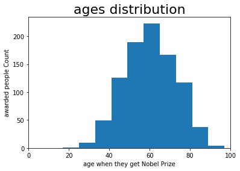

## Nobel Prize gender

> It appears that about six percent of Nobel Prize winners are women. I expected that the percentage of women would be less than men, but I did not expect that the difference would be this big.

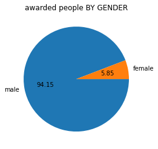

## Awarded people by category

> The Nobel Prize is given more to people in the field of medicine then physics.

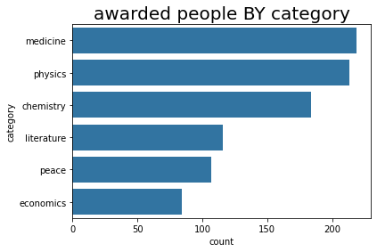

## Distribution of Nobel Prize by country

> The United States has the Most of the Nobel Prizes. USA, Great Britain, Deutschland(Germany) had the most wins.

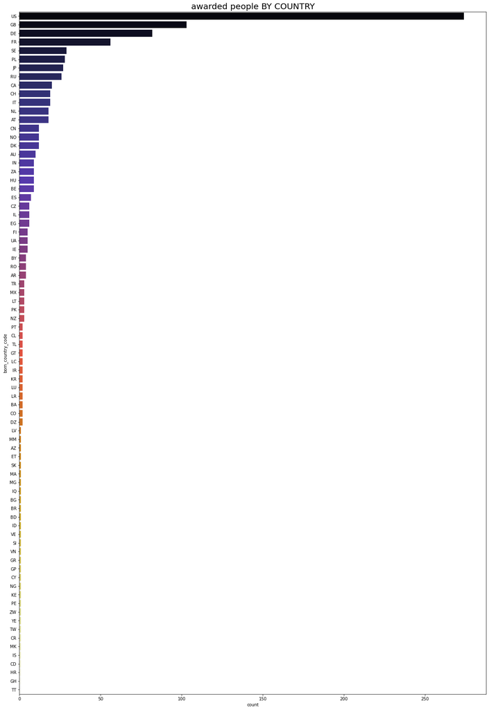

## The number of men and women over the decades

> over the years the proportion of women increases.

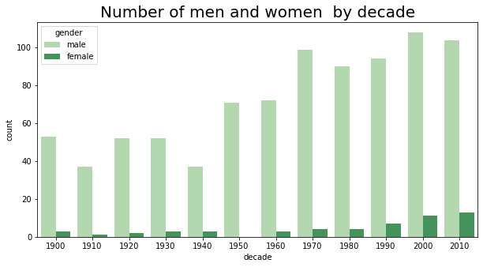

## Number of men and women by category

> Here we can see that women are interested in (peace&literature) then medicine but men get a lot of nobel prize at physics and medicine, but men get a lot of nobel prize at physics and medicine .

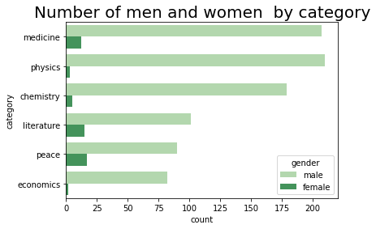

## Number of women by Country

> The United States has the Most of the woemn how win Nobel Prizes

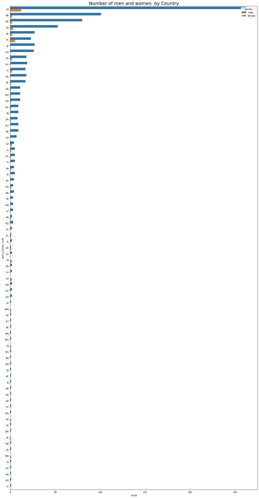

# category by Country

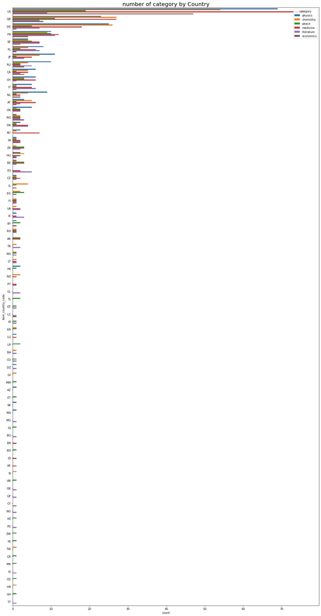

## Every winner age seperated by gender and prize category

> This shows that a very small percentage of women won the Nobel Prize in (physics,chemistry, economics). Many young ladies have won the Nobel Prize in peace before the age of thirty-five.

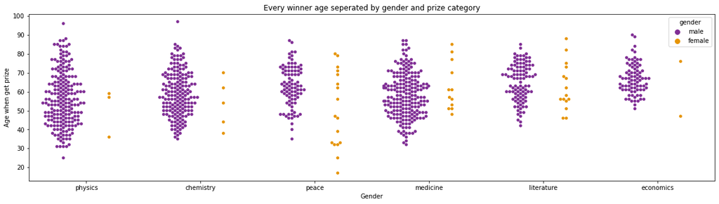